# Beer and Breweries

Tadd Backus & Austin Webb

2022-06-25

# Introduction and Overview

In this report, we explore the datasets you provided to us; the datasets that have information for various beers, and the breweries that produce them, in the USA. The steps and procedures taken for this analysis are detailed below. We start by looking at basic summary statistics, visual graphics, and at the statistical differences between ABV (alcohol by volume) and IBU (International Bitterness Units). We also looked at the differences between IPAs and other types of Ales.

The initial data provided were in two separate datasets, one for beers and one for breweries, which were later combined into a single dataset.

# GitHub

Our GitHub repository {https://github.com/tadbackus/beerAndBreweries} has this code we used, as well as previously used code. There are also older versions of the PowerPoint that we created.

- [`README.md`](https://github.com/tadbackus/beerAndBreweries/blob/main/README.md): This page shows an introduction to the analysis we ran. It also includes a few details about the datasets provided.
- [`Beers.csv`](https://github.com/tadbackus/beerAndBreweries/blob/main/Data/Beer.csv) and [`Breweries.csv`](https://github.com/tadbackus/beerAndBreweries/blob/main/Data/Breweries.csv) were provided and are the original datasets from which our merged dataset is produced.

Here we import all the necessary libraries and packages

We will read in the beer and brewery data provided

The beer dataset has 2,410 observations and seven columns. The brewery dataset has 558 observations four columns.

# Question 1

## Number of Breweries in each state

We will first look at a table that shows the number of breweries in each state. We will then look at a map of the USA that is color coded to visually show the amount of breweries in each state.

```
##  AK  AL  AR  AZ  CA  CO  CT  DC  DE  FL  GA  HI  IA  ID  IL  IN  KS  KY  LA  MA
##   7   3   2  11  39  47   8   1   2  15   7   4   5   5  18  22   3   4   5  23
##  MD  ME  MI  MN  MO  MS  MT  NC  ND  NE  NH  NJ  NM  NV  NY  OH  OK  OR  PA  RI
##   7   9  32  12   9   2   9  19   1   5   3   3   4   2  16  15   6  29  25   5
##  SC  SD  TN  TX  UT  VA  VT  WA  WI  WV  WY
##   4   1   3  28   4  16  10  23  20   1   4
```

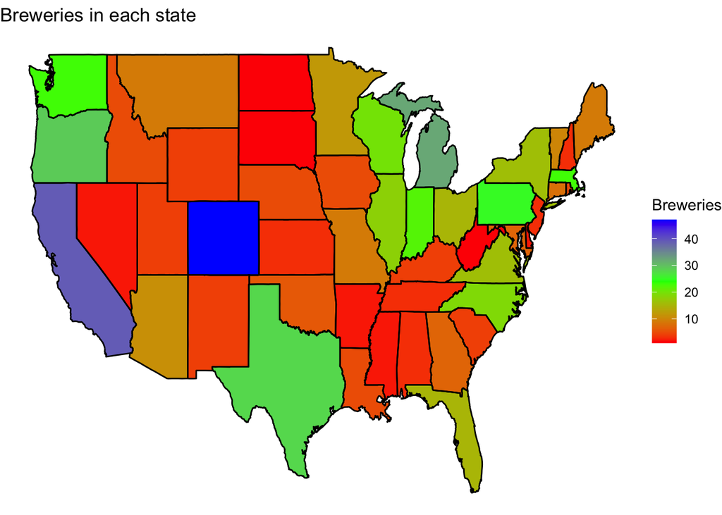

We can see from the table, and the map as secondary evidence, that the state with the most breweries is Colorado with 47 breweries.

# Question 2

## Combining the beer and brewery data

Here is where we merge the two datsets into one. We do this by merging on the ‘Brewery_id’ from the beer dataset and ‘Brew_ID’ from the brewery dataset.

```
##   Brewery_id        Name.x Beer_ID   ABV IBU
## 1          1  Get Together    2692 0.045  50
## 2          1 Maggie's Leap    2691 0.049  26
## 3          1    Wall's End    2690 0.048  19
## 4          1       Pumpion    2689 0.060  38
## 5          1    Stronghold    2688 0.060  25
## 6          1   Parapet ESB    2687 0.056  47
##                                 Style Ounces             Name.y        City
## 1                        American IPA     16 NorthGate Brewing  Minneapolis
## 2                  Milk / Sweet Stout     16 NorthGate Brewing  Minneapolis
## 3                   English Brown Ale     16 NorthGate Brewing  Minneapolis
## 4                         Pumpkin Ale     16 NorthGate Brewing  Minneapolis
## 5                     American Porter     16 NorthGate Brewing  Minneapolis
## 6 Extra Special / Strong Bitter (ESB)     16 NorthGate Brewing  Minneapolis
##   State
## 1    MN
## 2    MN
## 3    MN
## 4    MN
## 5    MN
## 6    MN
```

```
##      Brewery_id                    Name.x Beer_ID   ABV IBU
## 2405        556             Pilsner Ukiah      98 0.055  NA
## 2406        557  Heinnieweisse Weissebier      52 0.049  NA
## 2407        557           Snapperhead IPA      51 0.068  NA
## 2408        557         Moo Thunder Stout      50 0.049  NA
## 2409        557         Porkslap Pale Ale      49 0.043  NA
## 2410        558 Urban Wilderness Pale Ale      30 0.049  NA
##                        Style Ounces                        Name.y          City
## 2405         German Pilsener     12         Ukiah Brewing Company         Ukiah
## 2406              Hefeweizen     12       Butternuts Beer and Ale Garrattsville
## 2407            American IPA     12       Butternuts Beer and Ale Garrattsville
## 2408      Milk / Sweet Stout     12       Butternuts Beer and Ale Garrattsville
## 2409 American Pale Ale (APA)     12       Butternuts Beer and Ale Garrattsville
## 2410        English Pale Ale     12 Sleeping Lady Brewing Company     Anchorage
##      State
## 2405    CA
## 2406    NY
## 2407    NY
## 2408    NY
## 2409    NY
## 2410    AK
```

We then look at the first six and final six observations from the new merged dataset.

# Question 3

## Missing values

We use a simple formula here to count the number of missing values in each column.

```
## Brewery_id     Name.x    Beer_ID        ABV        IBU      Style     Ounces
##          0          0          0         62       1005          0          0
##     Name.y       City      State
##          0          0          0
```

From this table, we see that there are 62 missing values for ABV and 1005 missing values for IBU.

## Plotting missing values

We now look at a visually appealing way to see the missing data

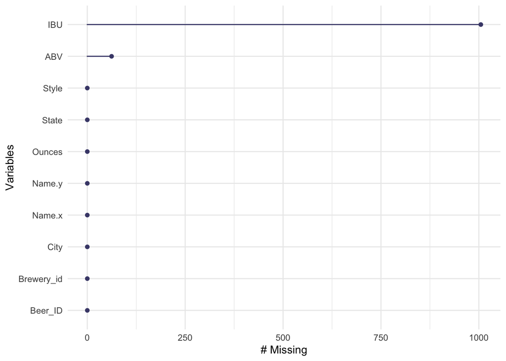

## Categorizing beer type

We want to group the different beers by type of beer. We do this by creating a list of common beer types and assigning by the name of the beer.

```
##         Ale       Cider       Fruit  Hefeweizen         IPA      Kölsch
##         976          37          49          40         558          42
##       Lager Oktoberfest       Other     Pilsner      Porter       Stout
##         158          30         204          91          74         100
##     Witbier
##          51
```

From this grouping, we see that there are 976 ales, 558 IPAs, and a variety of other beer types.

We use this code to see how the ABV and IBU compare for all the different types of beers

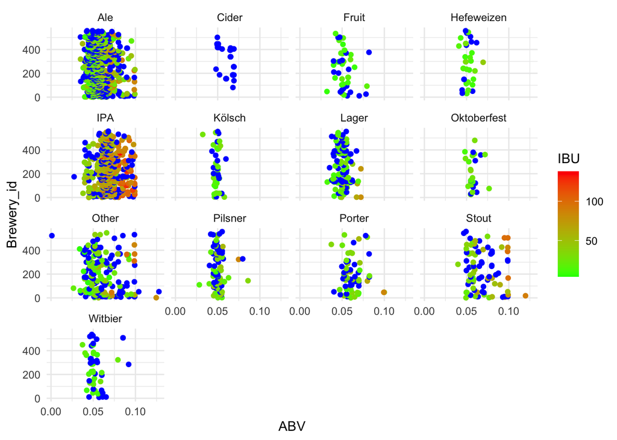

From these plots, we can see that all the ‘ciders’ have missing values. We will take care of these in the next chunk of code.

## Removing Cider and verifying

We create a new df with the ciders filtered out. we then recreate the above plots that show how the ABV and IBU compare for all the different types of beers

```
##         Ale       Fruit  Hefeweizen         IPA      Kölsch       Lager
##         976          49          40         558          42         158
## Oktoberfest       Other     Pilsner      Porter       Stout     Witbier
##          30         204          91          74         100          51
```

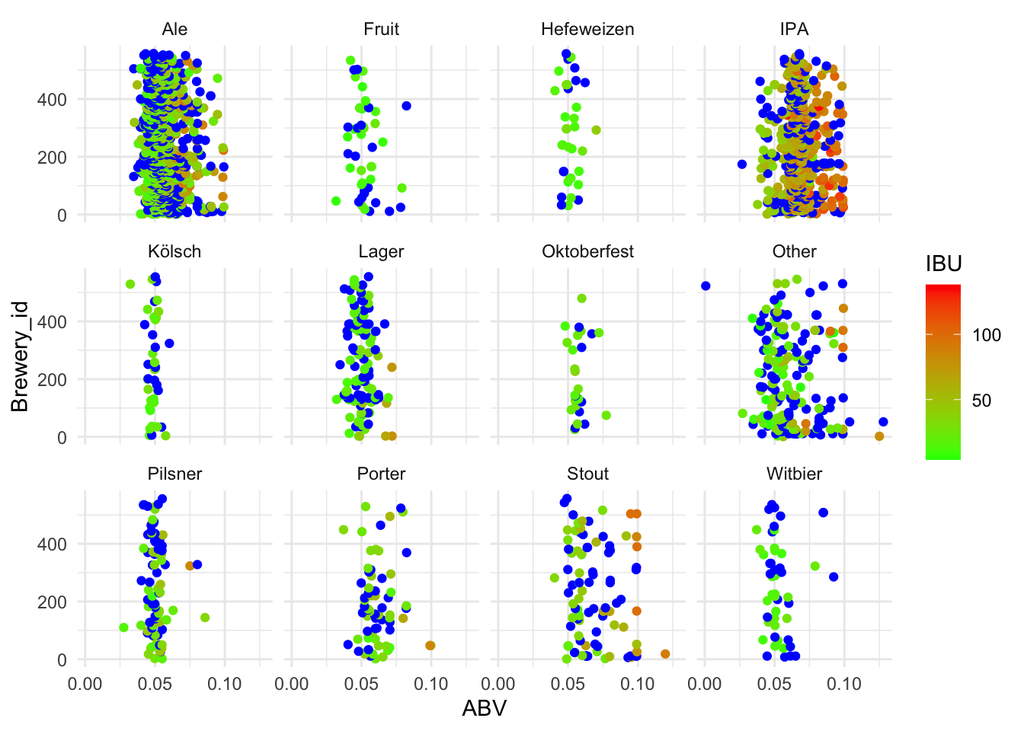

## kNN Imputation

This is where we start the kNN process. We impute the missing values with a kNN model.

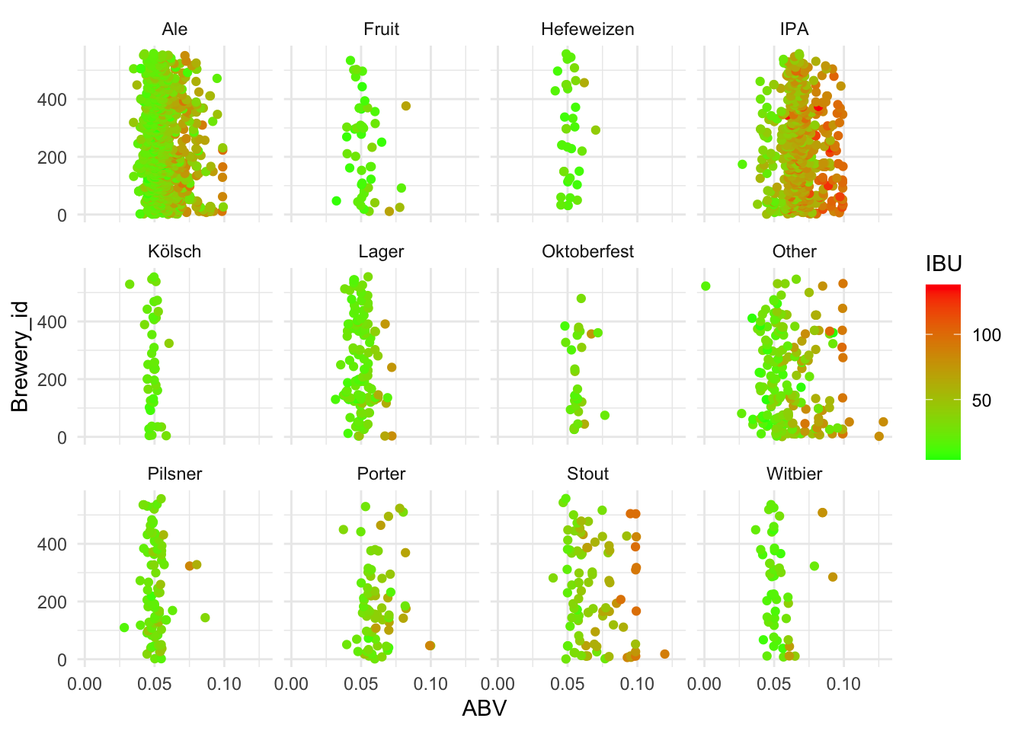

From the plots above, we see that the missing values have been accurately imputed with five of their nearest neighbors.

# Question 4

## Finding median ABV and IBU per State

We will create new dataframes that are grouped by state and have the median ABV/IBU.  
We will use these new dataframes to create barplots to visually see the differences of medians for each state.  
This will be followed by more USA heatmaps.  
These ones showing the median ABV/IBU.

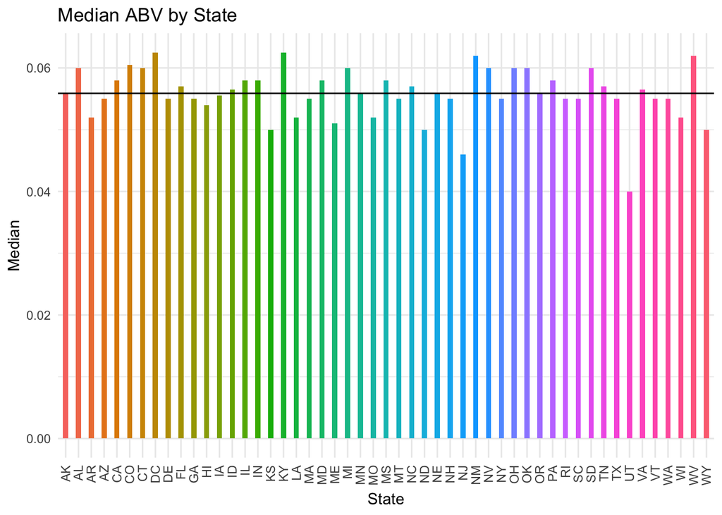

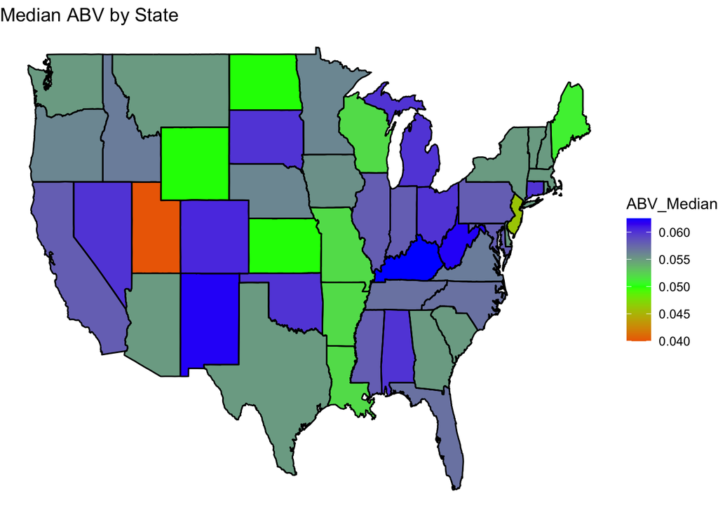

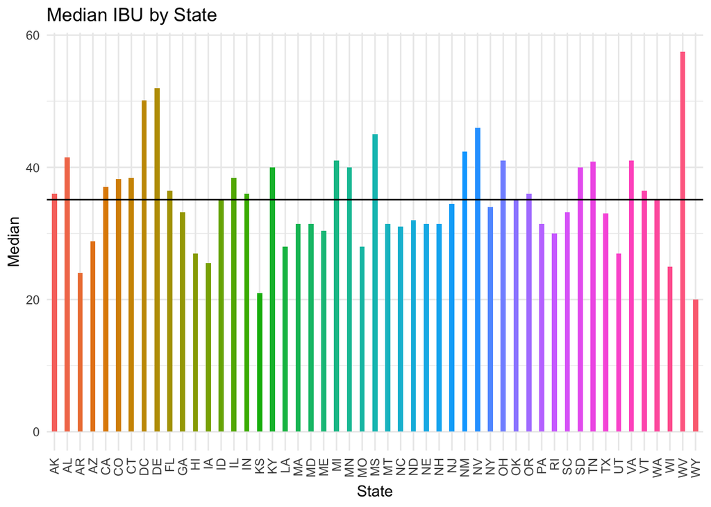

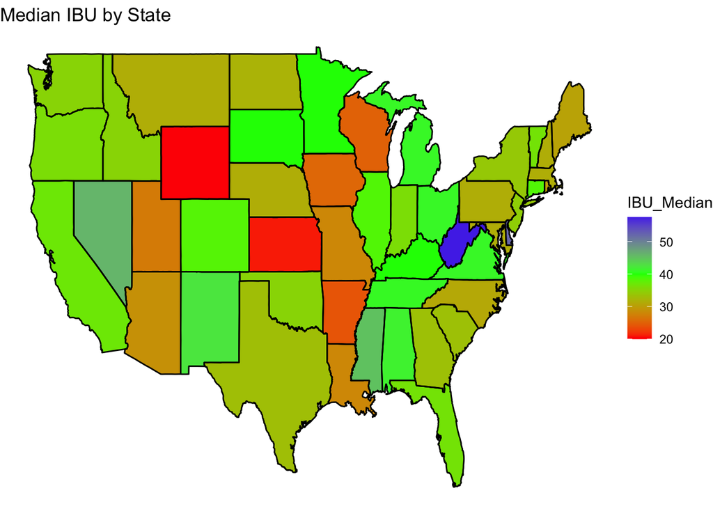

# Question 5

## Max ABV

We changed the names of two columns that were automatically named from when we merged the datasets.  
We extract the observation with the highest ABV and put it in a dataframe.

```
##   Brewery_id                                            Beer Name Beer_ID   ABV
## 1         52 Lee Hill Series Vol. 5 - Belgian Style Quadrupel Ale    2565 0.128
##   IBU            Style Ounces            Brewery Name    City State beerCat
## 1  81 Quadrupel (Quad)   19.2 Upslope Brewing Company Boulder    CO   Other
```

The max ABV is found in Lee Hill Series Vol. 5 - Belgian Style Quadrupel Ale, which has an ABV of .128

## Max IBU

We extract the observation with the highest IBU and put it in a dataframe.

```
##   Brewery_id                 Beer Name Beer_ID   ABV IBU
## 1        375 Bitter Bitch Imperial IPA     980 0.082 138
##                            Style Ounces            Brewery Name    City State
## 1 American Double / Imperial IPA     12 Astoria Brewing Company Astoria    OR
##   beerCat
## 1     IPA
```

The max IBU is found in Bitter Bitch Imperial IPA, with an IBU of 138.

# Question 6

## Stats of ABV

We made a table that shows basic summary statistics for the ABV. We also made a couple plots to visually show these summary statistics.

```
##    Min. 1st Qu.  Median    Mean 3rd Qu.    Max.
## 0.00100 0.05000 0.05600 0.05976 0.06700 0.12800
```

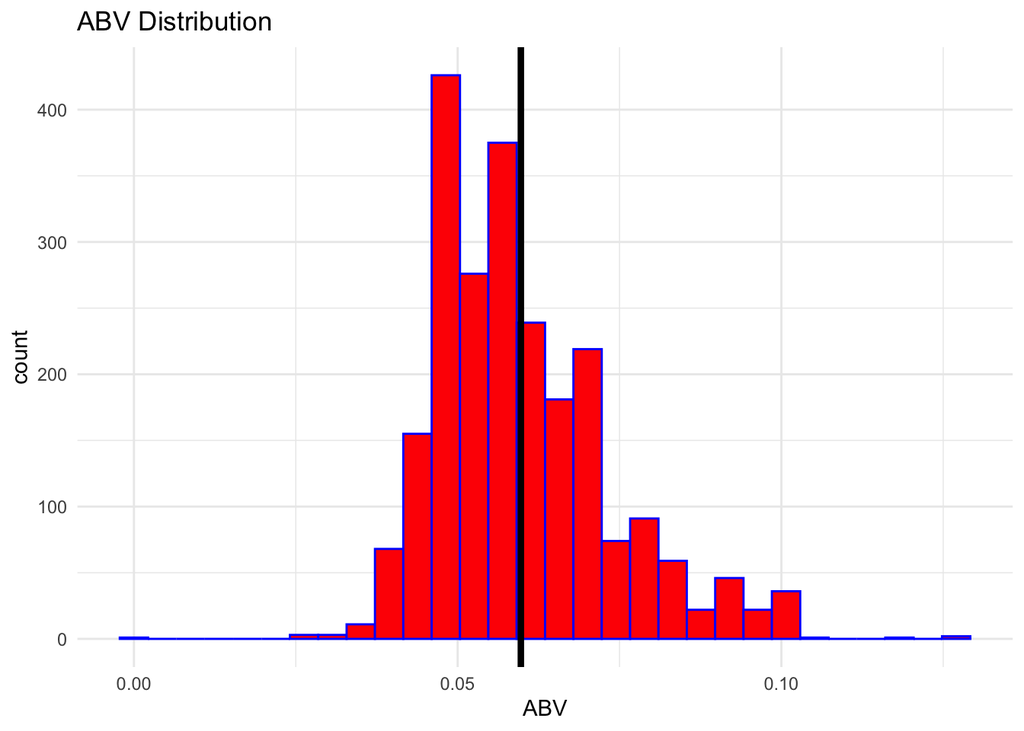

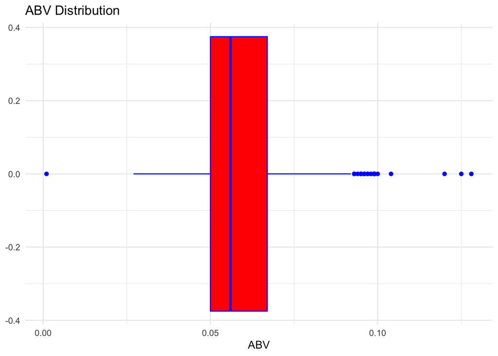

We can see basic summary statistics in the table below: Min. 1st Qu. Median Mean 3rd Qu. Max. 0.00100 0.05000 0.05600 0.05976 0.06700 0.12800

# Question 7

## ABV vs IBU scatter

We created a scatterplot to help see the correlation between ABV and IBU. We also looked at the exact correlation coefficient.

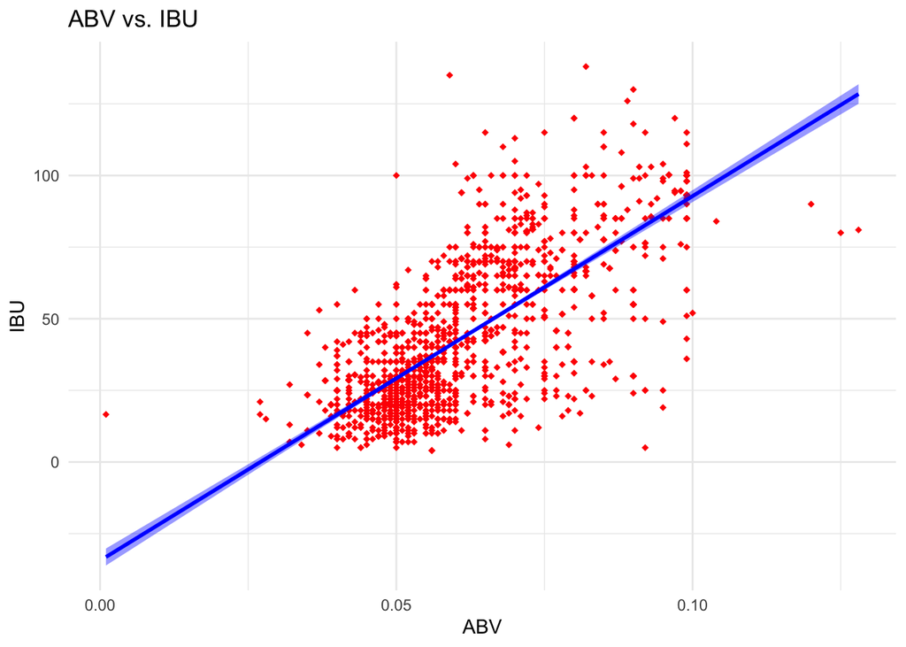

```
## [1] 0.726897
```

# Question 8

## IPA vs other Ales

We made a new dataframe that only contains IPA and Ale beer types. We built a scatterplot to help visualize the differences between the two types of beer and the ABV and IBU.

```
##    Brewery_id     Beer Name            Beer_ID            ABV
##  Min.   :  1.0   Length:1492        Min.   :   1.0   Min.   :0.02700
##  1st Qu.: 93.0   Class :character   1st Qu.: 792.8   1st Qu.:0.05100
##  Median :205.0   Mode  :character   Median :1474.5   Median :0.06000
##  Mean   :230.1                      Mean   :1431.8   Mean   :0.06131
##  3rd Qu.:361.2                      3rd Qu.:2076.2   3rd Qu.:0.07000
##  Max.   :558.0                      Max.   :2692.0   Max.   :0.09900
##
##       IBU            Style               Ounces      Brewery Name
##  Min.   :  4.00   Length:1492        Min.   :12.00   Length:1492
##  1st Qu.: 27.00   Class :character   1st Qu.:12.00   Class :character
##  Median : 40.60   Mode  :character   Median :12.00   Mode  :character
##  Mean   : 46.81                      Mean   :13.59
##  3rd Qu.: 65.00                      3rd Qu.:16.00
##  Max.   :138.00                      Max.   :32.00
##
##      City               State           beerCat
##  Length:1492         CO    :170   Ale       :944
##  Class :character    CA    :123   IPA       :548
##  Mode  :character    IN    : 87   Fruit     :  0
##                      MI    : 85   Hefeweizen:  0
##                      OR    : 84   Kölsch    :  0
##                      TX    : 73   Lager     :  0
##                     (Other):870   (Other)   :  0
```

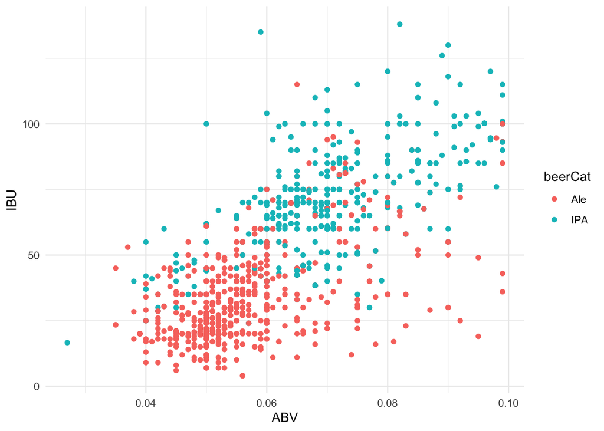

# Question 9

## kNN Classifier

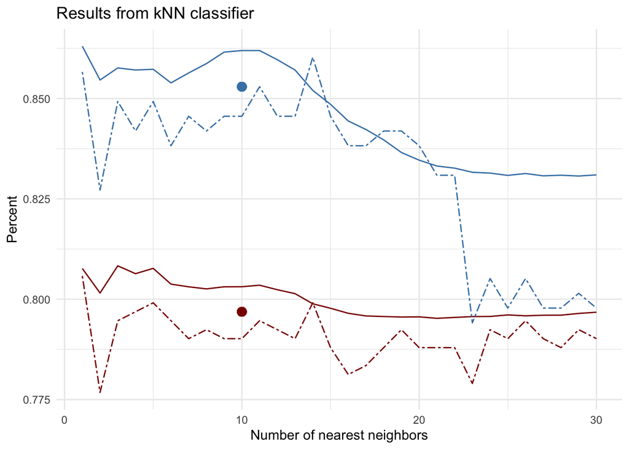

# Extra Analysis

## Most popular beer types in each state

We plot the beer with a bar chart for each state with the color representing the amount of each type.  
Then we plot the most popular type on a map.

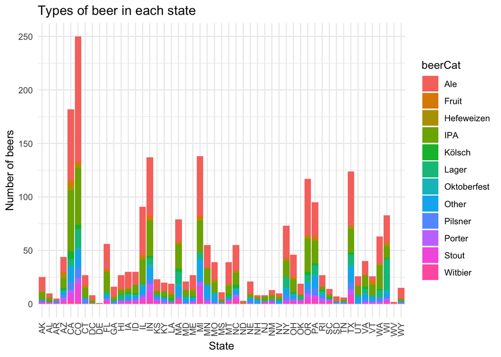

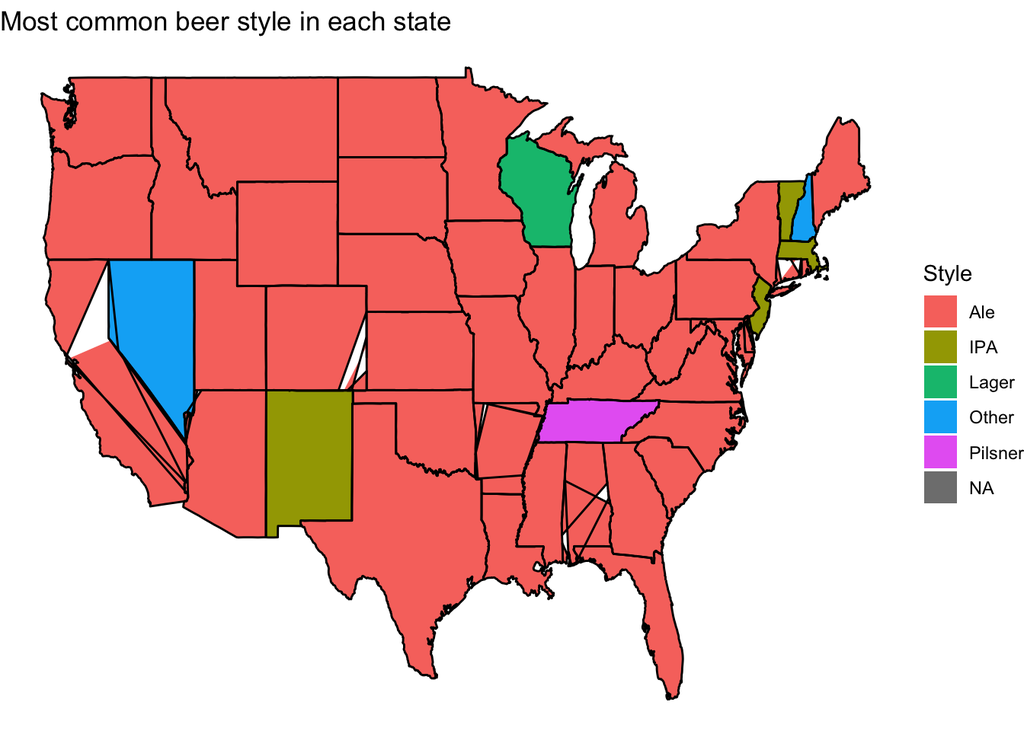

Ale’s are the most common beer in 42 states, with IPA’s the most common in 4 states.  
This is partially caused by the way Ale’s were categorized, consisting of multiple types of ales.